# Incremento_popolazione_Mortalita'_infantile

```python
import numpy as np, pandas as pd
```

## Prendiamo il nostro database generale, che riguarda tutti i Paesi e le zone strategiche del mondo, per una serie di indicatori che vanno dal 1960 al 2016.

```python
pd.set_option('display.float_format', lambda x: '%.2f' % x)
df2 = pd.read_csv("D:\\Admin_1\\Download\\DataWorld\\Health\\HNP_StatsData.csv")
df2 = df2.drop('Indicator Code', axis = 1)
#df2[df2['Country Name'] == 'Italy']
df2 = df2.set_index('Country Name')
df2.head()
df2 = df2.drop('Country Code', axis=1)
df2.head()
```

| Country Name | Indicator Name | 1960 | 1961 | 1962 | 1963 | 1964 | 1965 | 1966 | 1967 | 1968 | ... | 2009 | 2010 | 2011 | 2012 | 2013 | 2014 | 2015 | 2016 | 2017 | Unnamed: 62 |
| --- | --- | --- | --- | --- | --- | --- | --- | --- | --- | --- | --- | --- | --- | --- | --- | --- | --- | --- | --- | --- | --- |
| Arab World | % of females ages 15-49 having comprehensive c... | nan | nan | nan | nan | nan | nan | nan | nan | nan | ... | nan | nan | nan | nan | nan | nan | nan | nan | nan | nan |
| Arab World | % of males ages 15-49 having comprehensive cor... | nan | nan | nan | nan | nan | nan | nan | nan | nan | ... | nan | nan | nan | nan | nan | nan | nan | nan | nan | nan |
| Arab World | Adolescent fertility rate (births per 1,000 wo... | 134.22 | 134.84 | 135.57 | 135.44 | 135.27 | 134.95 | 134.23 | 133.36 | 130.87 | ... | 50.10 | 49.90 | 49.72 | 49.54 | 49.11 | 48.65 | 48.11 | 47.44 | nan | nan |
| Arab World | Adults (ages 15+) and children (0-14 years) li... | nan | nan | nan | nan | nan | nan | nan | nan | nan | ... | nan | nan | nan | nan | nan | nan | nan | nan | nan | nan |
| Arab World | Adults (ages 15+) and children (ages 0-14) new... | nan | nan | nan | nan | nan | nan | nan | nan | nan | ... | nan | nan | nan | nan | nan | nan | nan | nan | nan | nan |

5 rows × 60 columns

Selezioniamo l'indicatore relativo alla Popolazione.  
Vediamo sotto le prime cinque zone strategiche del database e la corrispondente popolazione dal 1960 al 2016.

```python
popTot = df2[df2['Indicator Name']=='Population, total']
popTot = popTot.reindex(columns = popTot.columns[:-2])
popTot.head()
```

| Country Name | Indicator Name | 1960 | 1961 | 1962 | 1963 | 1964 | 1965 | 1966 | 1967 | 1968 | ... | 2007 | 2008 | 2009 | 2010 | 2011 | 2012 | 2013 | 2014 | 2015 | 2016 |
| --- | --- | --- | --- | --- | --- | --- | --- | --- | --- | --- | --- | --- | --- | --- | --- | --- | --- | --- | --- | --- | --- |
| Arab World | Population, total | 92490932.0000 | 95044497.0000 | 97682294.0000 | 100411076.0000 | 103239902.0000 | 106174988.0000 | 109230593.0000 | 112406932.0000 | 115680165.0000 | ... | 331653797.0000 | 339825483.0000 | 348145094.0000 | 356508908.0000 | 364895878.0000 | 373306993.0000 | 381702086.0000 | 390043028.0000 | 398304960.0000 | 406452690.0000 |
| Caribbean small states | Population, total | 4198307.0000 | 4277802.0000 | 4357746.0000 | 4436804.0000 | 4513246.0000 | 4585777.0000 | 4653919.0000 | 4718167.0000 | 4779624.0000 | ... | 6851221.0000 | 6895315.0000 | 6939534.0000 | 6984096.0000 | 7029022.0000 | 7074129.0000 | 7118888.0000 | 7162679.0000 | 7204948.0000 | 7245472.0000 |
| Central Europe and the Baltics | Population, total | 91401583.0000 | 92237118.0000 | 93014890.0000 | 93845749.0000 | 94722599.0000 | 95447065.0000 | 96148635.0000 | 97043587.0000 | 97882394.0000 | ... | 105504531.0000 | 105126686.0000 | 104924372.0000 | 104543801.0000 | 104174038.0000 | 103935318.0000 | 103713726.0000 | 103496179.0000 | 103257751.0000 | 102991323.0000 |
| Early-demographic dividend | Population, total | 979287407.0000 | 1002523576.0000 | 1026586722.0000 | 1051414973.0000 | 1077037307.0000 | 1103433059.0000 | 1130587356.0000 | 1158571169.0000 | 1187273756.0000 | ... | 2778276175.0000 | 2821797496.0000 | 2865439651.0000 | 2909410986.0000 | 2953406021.0000 | 2997066325.0000 | 3040700765.0000 | 3084236443.0000 | 3127578757.0000 | 3170657660.0000 |
| East Asia & Pacific | Population, total | 1039944591.0000 | 1043546746.0000 | 1058028198.0000 | 1083802302.0000 | 1109204182.0000 | 1135650893.0000 | 1165517897.0000 | 1194424325.0000 | 1223721287.0000 | ... | 2162102842.0000 | 2177421109.0000 | 2192351452.0000 | 2207154891.0000 | 2221934234.0000 | 2237082761.0000 | 2252310372.0000 | 2267745316.0000 | 2283107673.0000 | 2298727229.0000 |

5 rows × 58 columns

Analizziamo quali sono le zone strategiche e i Paesi dove c'è stato un maggiore incremento della popolazione in valore assoluto tra il 1960 e il 2016.  
Gli Stati in cui la popolazione è aumentata maggiormente in valore assoluto sono l'India (un incremento di 874,7 milioni negli ultimi 56 anni), seguita dalla Cina (un incremento di 711 milioni).  
Terza l'Indonesia con un incremento di 173 milioni di persone.

```python
def f_1960_2016(df):
    return df['2016']-df['1960']

f_1960_2016(popTot).sort_values(ascending=False).head(40)
```

```
Country Name
World                                                  4411866832.00
Low & middle income                                    3976522496.00
Middle income                                          3471919983.00
Early-demographic dividend                             2191370253.00
Lower middle income                                    2061351758.00
Upper middle income                                    1410568225.00
East Asia & Pacific                                    1258782638.00
South Asia                                             1194558048.00
South Asia (IDA & IBRD)                                1194558048.00
Late-demographic dividend                              1167345130.00
East Asia & Pacific (excluding high income)            1159342799.00
East Asia & Pacific (IDA & IBRD countries)             1145374630.00
India                                                   874690746.00
Sub-Saharan Africa                                      804626738.00
Sub-Saharan Africa (IDA & IBRD countries)               804626738.00
Sub-Saharan Africa (excluding high income)              804573761.00
Least developed countries: UN classification            738645729.00
China                                                   711595000.00
Pre-demographic dividend                                690656262.00
Heavily indebted poor countries (HIPC)                  582107396.00
Low income                                              504602513.00
OECD members                                            501163511.00
High income                                             435344336.00
Latin America & Caribbean                               417234015.00
Latin America & the Caribbean (IDA & IBRD countries)    411177301.00
Latin America & Caribbean (excluding high income)       403847931.00
Fragile and conflict affected situations                383870950.00
Post-demographic dividend                               347946104.00
Middle East & North Africa                              331231415.00
Arab World                                              313961758.00
Middle East & North Africa (excluding high income)      275881289.00
Middle East & North Africa (IDA & IBRD countries)       271329723.00
Europe & Central Asia                                   244600894.00
Indonesia                                               173322941.00
North America                                           160833084.00
Pakistan                                                148295183.00
Europe & Central Asia (IDA & IBRD countries)            146651305.00
United States                                           142456513.00
Nigeria                                                 140851828.00
Europe & Central Asia (excluding high income)           138318668.00
dtype: float64
```

La popolazione italiana dal 1960 al 2016 è aumentata di piu' di 10 milioni. Un incremento del 20%.

```python
print('Incremento popolazione italiana 1960-2016 :', f_1960_2016(popTot).sort_values(ascending=False)['Italy'])
```

```
Incremento popolazione italiana 1960-2016 : 10427798.0
```

Qui sotto abbiamo la conferma che ci fa vedere l'andamento anno per anno della nostra nazione.

```python
popTot.loc['Italy'].to_frame().T
```

|  | Indicator Name | 1960 | 1961 | 1962 | 1963 | 1964 | 1965 | 1966 | 1967 | 1968 | ... | 2007 | 2008 | 2009 | 2010 | 2011 | 2012 | 2013 | 2014 | 2015 | 2016 |
| --- | --- | --- | --- | --- | --- | --- | --- | --- | --- | --- | --- | --- | --- | --- | --- | --- | --- | --- | --- | --- | --- |
| Italy | Population, total | 50199700.0000 | 50536350.0000 | 50879450.0000 | 51252000.0000 | 51675350.0000 | 52112350.0000 | 52519000.0000 | 52900500.0000 | 53235750.0000 | ... | 58438310.0000 | 58826731.0000 | 59095365.0000 | 59277417.0000 | 59379449.0000 | 59539717.0000 | 60233948.0000 | 60789140.0000 | 60730582.0000 | 60627498.0000 |

1 rows × 58 columns

```python
print('Italy: 1960->',popTot.loc['Italy']['1960'],' 2016->',popTot.loc['Italy']['2016'])
```

```
Italy: 1960-> 50199700.0  2016-> 60627498.0
```

Andiamo a vedere ora quali sono i Paesi dove la popolazione è piu' aumentata in termini relativi e non assoluti.  
Studiamo quindi l'andamento dei tassi di incremento della popolazione dal 1960 al 2016.

```python
def deltaperc(df):
    return (df['2016']-df['1960']) / df['1960']
```

```python
deltaperc(popTot).sort_values(ascending = False)
```

```
Country Name
United Arab Emirates             99.07
Qatar                            53.23
Kuwait                           14.03
Djibouti                         10.27
Jordan                            9.14
Bahrain                           7.77
Oman                              7.02
Saudi Arabia                      6.90
Cayman Islands                    6.73
St. Martin (French part)          6.47
Cote d'Ivoire                     5.66
Uganda                            5.11
Niger                             5.10
Turks and Caicos Islands          5.10
Kenya                             4.98
Andorra                           4.76
Gambia, The                       4.54
Tanzania                          4.52
Northern Mariana Islands          4.48
Zambia                            4.45
Yemen, Rep.                       4.33
Sudan                             4.25
Somalia                           4.20
Brunei Darussalam                 4.18
Congo, Dem. Rep.                  4.16
Angola                            4.11
Iraq                              4.10
Solomon Islands                   4.09
Mauritania                        4.01
Malawi                            4.00
                                  ...
European Union                    0.25
Finland                           0.24
Austria                           0.24
Belgium                           0.24
Barbados                          0.23
Dominica                          0.23
Italy                             0.21
Russian Federation                0.20
```

[output cut: 8 more lines]

```
St. Kitts and Nevis               0.07
Romania                           0.07
Ukraine                           0.05
Lithuania                         0.03
Georgia                           0.02
Croatia                           0.01
Hungary                          -0.02
Latvia                           -0.08
Bulgaria                         -0.09
Not classified                     nan
Eritrea                            nan
Serbia                             nan
Sint Maarten (Dutch part)          nan
West Bank and Gaza                 nan
Length: 259, dtype: float64
```

I due Stati dal maggior incremento relativo:  
1) Gli Emirati Arabi, da 92mila abitanti del 1960, sono passati a piu' di 9 milioni nel 2016. (un po' come Ancona che diventa New York in soli 56 anni)  
2) Il Qatar, da 47 mila abitanti del 1960, a piu' di 2 milioni e mezzo nel 2016. (un po' come Vasto che diventa Parigi)

```python
print('Emirati Arabi: 1960->',popTot.loc['United Arab Emirates']['1960'],' 2016->',popTot.loc['United Arab Emirates']['2016'])

print('Qatar: 1960->',popTot.loc['Qatar']['1960'],' 2016->',popTot.loc['Qatar']['2016'])
```

```
Emirati Arabi: 1960-> 92634.0  2016-> 9269612.0
Qatar: 1960-> 47384.0  2016-> 2569804.0
```

Mettiamo ora su grafico l'andamento assoluto della popolazione relativo a:  
1) Mondo  
2) India  
3) Cina  
4) Indonesia  
I primi 3 grafici sono scalati in miliardi (1e9 = 1 miliardo), mentre l'ultimo in centinaia di milioni (1e8 = 100 milioni).  
Da notare che Cina e India, da sole, costituiscono circa 1/3 dell'intera popolazione mondiale.

```python
import matplotlib.pyplot as plt

index = pd.to_datetime(popTot.loc['World'][1:].index)
```

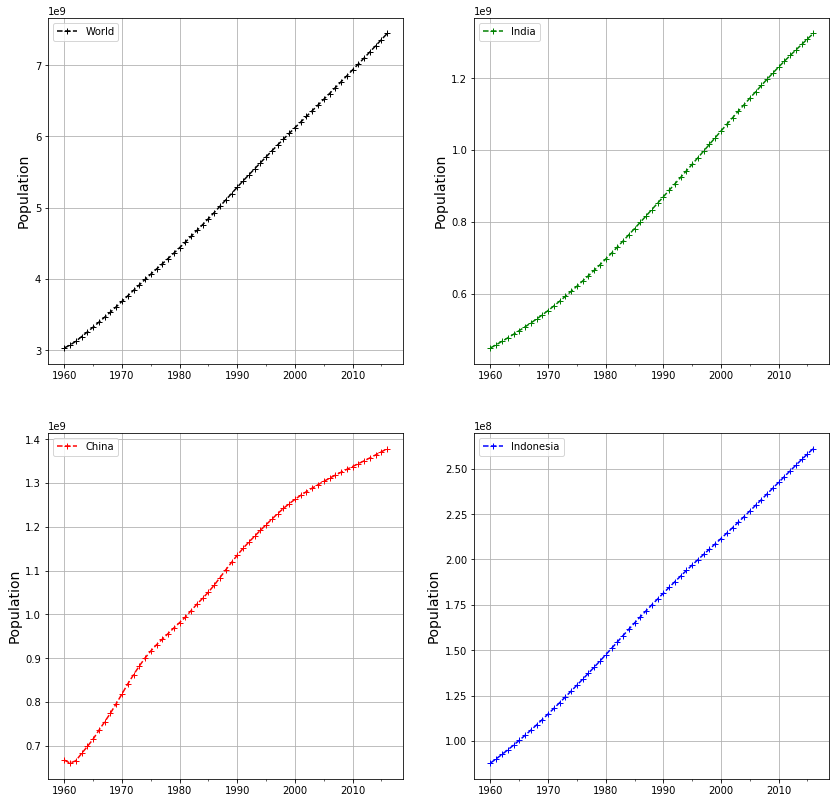

```python
fig, axes = plt.subplots(2,2, figsize=(14,14))
Grafici = []
Grafici.append(popTot.loc['World'][1:].to_frame().plot(x = index, ax = axes[0,0],grid=True, style='k+--'))#,logy=True))
Grafici.append(popTot.loc['China'][1:].to_frame().plot(x = index, ax = axes[1,0],grid=True,style='r+--'))#,logy=True))
Grafici.append(popTot.loc['India'][1:].to_frame().plot(x = index, ax = axes[0,1], grid=True,style='g+--'))#,logy=True))
Grafici.append(popTot.loc['Indonesia'][1:].to_frame().plot(x = index, ax = axes[1,1], grid=True,style='b+--'))#,logy=True));;
for graph in Grafici:
    graph.set_ylabel('Population', fontsize=14)
```

```
             World        China        India
1960 3032160395.00 667070000.00 449480608.00
1961 3073368588.00 660330000.00 458494963.00
1962 3126509808.00 665770000.00 467852537.00
1963 3191786431.00 682335000.00 477527970.00
1964 3257459749.00 698355000.00 487484535.00

             World         China         India
2012 7099548883.00 1350695000.00 1263065852.00
2013 7185078354.00 1357380000.00 1278562207.00
2014 7271228017.50 1364270000.00 1293859294.00
2015 7357369754.00 1371220000.00 1309053980.00
2016 7444027227.00 1378665000.00 1324171354.00
```

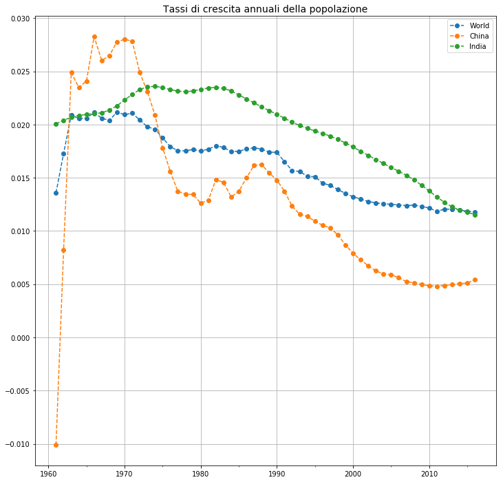

```python
fig, axes = plt.subplots(1,1, figsize=(12,12))
par = popTot.loc['World'][1:].to_frame().join([popTot.loc['China'][1:].to_frame(),popTot.loc['India'][1:].to_frame()])
par_perc = par.pct_change()
axes.set_title('Tassi di crescita annuali della popolazione', fontsize=14)
par_perc.plot(x = index, ax = axes, grid = True, style='o--');
#newticks = [str(i)+ ' mdl' for i in range(len(list(axes.get_yticklabels)))]
#newticks = [str(i)+ ' mld' for i in range(8)]
#axes.set_yticklabels(newticks)

print(par.head())
print()
print(par.tail())
print()
```

Passiamo ora allo studio della mortalita' infantile.  
Se possiamo ipotizzare che l'incremento relativo enorme della popolazione del mondo arabo sia conseguenza della valorizzazione delle loro risorse energetiche naturali come il petrolio, che hanno portato quei territori ad allinearsi alla ricchezza e allo stile di vita 'occidentale', trasformando alcuni citta' del mondo arabo in metropoli simili a quelle occidentali, per quanto riguarda l'incremento relativo della popolazione dell'Africa centrale, una possibile ipotesi è la diminuzione della mortalita' infantile.  
I dati che abbiamo relativi a questo indicatore pero' coprono solo gli ultimi 7 anni.  
Non molti, ma possiamo verificare se c'è comunque un trend netto in questi ultimi anni per quanto riguarda la mortalita' infantile in Africa.  
Se questa diminuisce anno per anno, allora si spiega meglio perche' la popolazione africana cresce con un'accelerazione maggiore di quasi tutto il resto del mondo.  
Prendiamo i dati sulla mortalita' infantile nel mondo dal 2009 al 2016.

```python
def f_2009_2016(df):
    return df['2016']-df['2009']
```

La tabella sotto mostra le prime cinque regioni del database relative alla mortalita'infantile.  
La statistica ci dice quanti bambini sotto i 5 anni muoiono su 1000 nascite.

```python
mort_rate = df2[df2['Indicator Name']=='Mortality rate, under-5 (per 1,000)']
anni = ['2009','2010','2011','2012','2013','2014','2015','2016']
mort_rate = mort_rate.reindex(columns = anni)
mort_rate.head()
```

| Country Name | 2009 | 2010 | 2011 | 2012 | 2013 | 2014 | 2015 | 2016 |
| --- | --- | --- | --- | --- | --- | --- | --- | --- |
| Arab World | 45.37 | 43.86 | 42.59 | 41.51 | 40.47 | 39.59 | 38.74 | 37.96 |
| Caribbean small states | 21.99 | 21.44 | 20.92 | 20.37 | 19.84 | 19.27 | 18.67 | 18.09 |
| Central Europe and the Baltics | 7.46 | 7.11 | 6.77 | 6.46 | 6.19 | 5.94 | 5.79 | 5.61 |
| Early-demographic dividend | 54.10 | 52.08 | 49.26 | 47.07 | 45.01 | 43.08 | 41.29 | 39.67 |
| East Asia & Pacific | 23.24 | 21.99 | 20.88 | 19.80 | 18.82 | 17.89 | 17.11 | 16.35 |

```python
peggioramenti = f_2009_2016(mort_rate).sort_values(ascending = False)
peggioramenti.head()
```

```
Country Name
Dominica               13.70
Grenada                 1.40
Macedonia, FYR          1.30
Syrian Arab Republic    1.10
Malaysia                0.40
dtype: float64
```

Se filtriamo invece gli Stati dove piu' si è abbassata la mortalita' infantile...i conti sembrano tornare.  
I Paesi africano sono quelli dove piu' si è abbassata la mortalita' infantile negli ultimi 7 anni.  
In Sierra Leone nel 2016, su 1000 nascite, muoiono 56 bambini in meno rispetto al 2009.  
La mortalita' infantile quindi in Africa si sta abbassando molto, e cio' conferma la nostra ipotesi iniziale.

```python
miglioramenti = f_2009_2016(mort_rate).sort_values()
miglioramenti.head(10)
```

```
Country Name
Sierra Leone   -56.1000
Angola         -45.8000
Malawi         -40.6000
Niger          -40.3000
Burkina Faso   -39.0000
Zimbabwe       -38.5000
Cameroon       -34.8000
Swaziland      -34.5000
Mozambique     -34.4000
Uganda         -33.4000
dtype: float64
```

Andamento mortalita' infantile 2009-2016 in Sierra Leone:

```python
mort_rate = mort_rate.reindex(columns = anni)

mort_rate.loc['Sierra Leone']
```

```
2009   169.60
2010   159.70
2011   149.80
2012   140.40
2013   132.00
2014   124.90
2015   118.80
2016   113.50
Name: Sierra Leone, dtype: float64
```

Cio' non significa ovviamente che la situazione sia rosea in Africa. E' ancora la regione che presenta di gran lunga i piu' alti tassi di mortalita' infantile, nonostante gli evidenti miglioramenti degli ultimi 7 anni.  
Sotto possiamo osservare gli Stati che hanno la mortalita' infantile piu' elevata nel mondo.  
L'Africa ha ancora tassi molto alti.

```python
high_mort_rate = mort_rate.sort_values(by='2016', ascending = False)
```

```python
high_mort_rate.head(20)
```

| Country Name | 2009 | 2010 | 2011 | 2012 | 2013 | 2014 | 2015 | 2016 |
| --- | --- | --- | --- | --- | --- | --- | --- | --- |
| Somalia | 163.7000 | 159.2000 | 154.4000 | 149.8000 | 145.2000 | 140.7000 | 136.7000 | 132.5000 |
| Chad | 153.7000 | 149.7000 | 145.7000 | 141.8000 | 138.1000 | 134.5000 | 130.9000 | 127.3000 |
| Central African Republic | 152.7000 | 148.9000 | 145.2000 | 141.3000 | 137.7000 | 133.6000 | 128.8000 | 123.6000 |
| Sierra Leone | 169.6000 | 159.7000 | 149.8000 | 140.4000 | 132.0000 | 124.9000 | 118.8000 | 113.5000 |
| Mali | 141.7000 | 136.5000 | 131.3000 | 126.6000 | 122.1000 | 118.3000 | 114.2000 | 110.6000 |
| Nigeria | 134.8000 | 129.6000 | 124.6000 | 120.0000 | 115.6000 | 111.6000 | 108.0000 | 104.3000 |
| Benin | 113.2000 | 111.1000 | 109.2000 | 107.2000 | 105.1000 | 102.8000 | 100.3000 | 97.6000 |
| Congo, Dem. Rep. | 119.6000 | 115.6000 | 111.7000 | 108.1000 | 104.4000 | 101.0000 | 97.6000 | 94.3000 |
| Lesotho | 103.4000 | 99.7000 | 98.0000 | 97.6000 | 98.5000 | 98.3000 | 97.9000 | 93.5000 |
| Cote d'Ivoire | 112.8000 | 110.5000 | 107.7000 | 104.9000 | 101.7000 | 98.3000 | 95.1000 | 91.8000 |
| Niger | 131.6000 | 123.3000 | 115.8000 | 109.2000 | 104.0000 | 99.2000 | 95.0000 | 91.3000 |
| Equatorial Guinea | 114.4000 | 110.6000 | 107.0000 | 103.7000 | 100.4000 | 97.1000 | 94.0000 | 90.9000 |
| South Sudan | 117.0000 | 112.5000 | 108.3000 | 104.3000 | 100.6000 | 96.9000 | 93.8000 | 90.7000 |
| Guinea | 113.4000 | 109.4000 | 105.6000 | 102.0000 | 98.6000 | 95.2000 | 92.0000 | 89.0000 |
| Guinea-Bissau | 119.9000 | 114.0000 | 108.5000 | 103.5000 | 99.0000 | 94.9000 | 91.3000 | 88.1000 |
| Burkina Faso | 123.6000 | 116.4000 | 109.6000 | 103.3000 | 97.7000 | 92.8000 | 88.5000 | 84.6000 |
| Angola | 128.3000 | 119.4000 | 111.0000 | 103.5000 | 96.8000 | 91.2000 | 86.5000 | 82.5000 |
| Mauritania | 100.2000 | 97.4000 | 94.6000 | 91.9000 | 89.4000 | 86.7000 | 83.9000 | 81.4000 |
| Pre-demographic dividend | 107.8385 | 103.3274 | 98.9358 | 94.8405 | 90.9877 | 87.4076 | 84.0884 | 80.9958 |
| Cameroon | 114.5000 | 108.3000 | 102.5000 | 97.0000 | 91.9000 | 87.5000 | 83.3000 | 79.7000 |

Nonostante la situazione ancora drammatica, nel 2009 la situazione era peggiore in ognuno di questi Stati.

```python
high_mort_rate_09_16 = high_mort_rate[['2009','2016']]
high_mort_rate_09_16.head(15)
```

| Country Name | 2009 | 2016 |
| --- | --- | --- |
| Somalia | 163.7000 | 132.5000 |
| Chad | 153.7000 | 127.3000 |
| Central African Republic | 152.7000 | 123.6000 |
| Sierra Leone | 169.6000 | 113.5000 |
| Mali | 141.7000 | 110.6000 |
| Nigeria | 134.8000 | 104.3000 |
| Benin | 113.2000 | 97.6000 |
| Congo, Dem. Rep. | 119.6000 | 94.3000 |
| Lesotho | 103.4000 | 93.5000 |
| Cote d'Ivoire | 112.8000 | 91.8000 |
| Niger | 131.6000 | 91.3000 |
| Equatorial Guinea | 114.4000 | 90.9000 |
| South Sudan | 117.0000 | 90.7000 |
| Guinea | 113.4000 | 89.0000 |
| Guinea-Bissau | 119.9000 | 88.1000 |

Nell'ultimo grafico sotto sono presenti tutti gli Stati con la maggior mortalita' infantile.  
Da sx verso dx gli Stati con la piu' alta mortalita' infantile nel 2016.  
Si apprezza visivamente subito come nel 2009 la situazione fosse ancora piu' catastrofica.

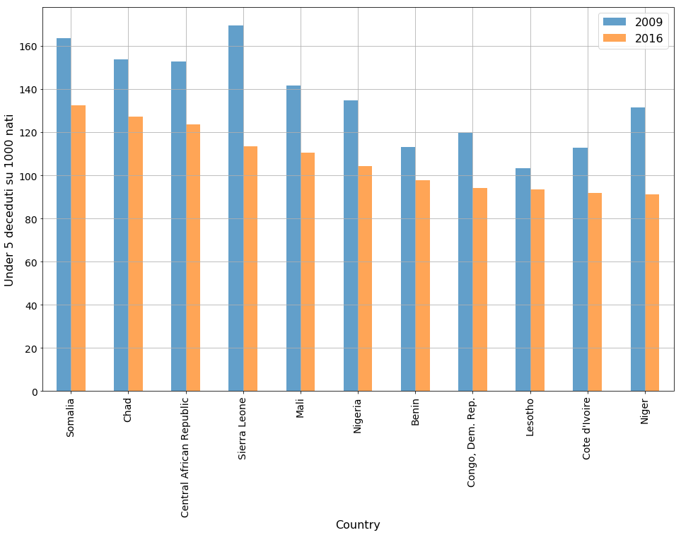

```python
ax = high_mort_rate_09_16.iloc[:11,:].plot.bar(figsize=(16,10), grid = True, alpha=0.7);
ax.set_ylabel('Under 5 deceduti su 1000 nati', fontsize=16)
ax.tick_params(axis='both', labelsize=14)
ax.set_xlabel('Country',fontsize=16);
ax.legend(prop={'size': 16});
```